# Does Not Playing Hockey Make You Worse at Hockey? Project Progress 7-21-22

### Refit Regression Models

#### MLR with interactions that make sense

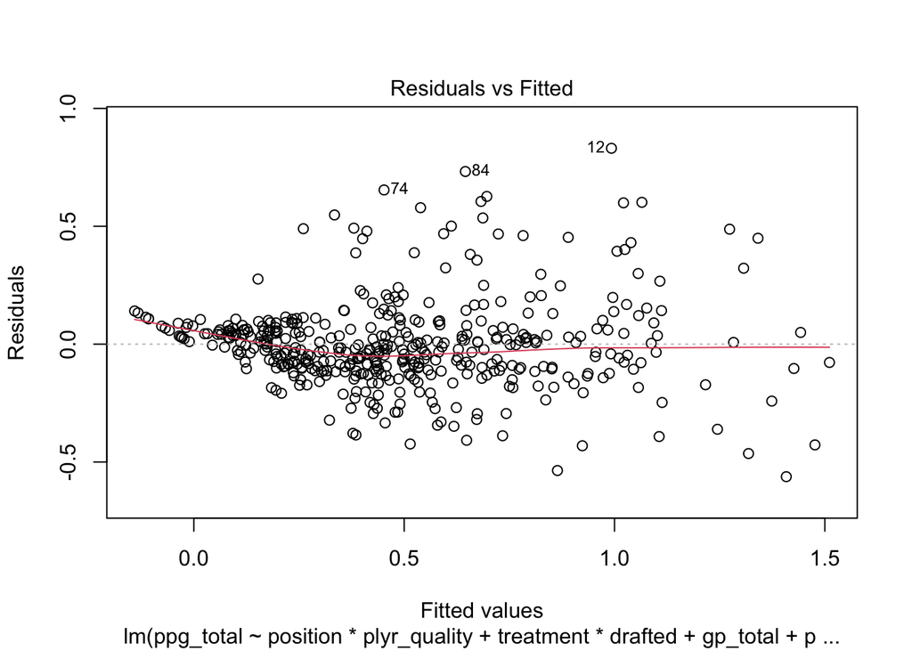

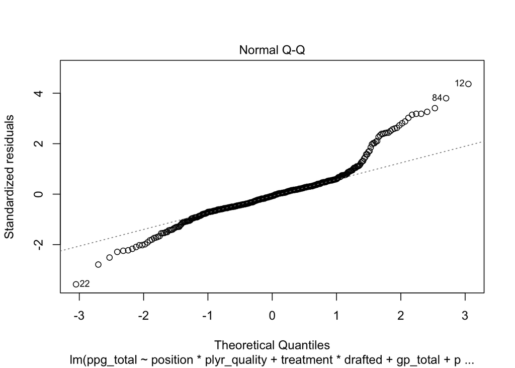

```
##
## Call:
## lm(formula = ppg_total ~ position * plyr_quality + treatment *
##     drafted + gp_total + plyr_quality * gp_total + plyr_quality *
##     drafted + age_continuous * plyr_quality + season, data = ohl_filtered)
##
## Residuals:
##      Min       1Q   Median       3Q      Max
## -0.56219 -0.10026 -0.01353  0.06968  0.83082
##
## Coefficients:
##                               Estimate Std. Error t value Pr(>|t|)
## (Intercept)                  0.6487089  0.2993550   2.167  0.03079 *
## positionF                    0.1050757  0.0329205   3.192  0.00152 **
## plyr_quality                 0.2821307  0.5193237   0.543  0.58723
## treatmentPlayed              0.0019808  0.0336923   0.059  0.95315
## draftedTRUE                  0.0859495  0.0444539   1.933  0.05384 .
## gp_total                     0.0031135  0.0007901   3.940 9.51e-05 ***
## age_continuous              -0.0482747  0.0174768  -2.762  0.00599 **
## season2021-2022              0.3427863  0.0337114  10.168  < 2e-16 ***
## positionF:plyr_quality      -0.0270689  0.0968855  -0.279  0.78008
## treatmentPlayed:draftedTRUE  0.0327579  0.0589740   0.555  0.57887
## plyr_quality:gp_total        0.0008258  0.0020820   0.397  0.69185
## plyr_quality:draftedTRUE    -0.0525461  0.0888778  -0.591  0.55469
## plyr_quality:age_continuous  0.0325024  0.0285984   1.137  0.25638
## ---
## Signif. codes:  0 '***' 0.001 '**' 0.01 '*' 0.05 '.' 0.1 ' ' 1
##
## Residual standard error: 0.1935 on 425 degrees of freedom
## Multiple R-squared:  0.7396, Adjusted R-squared:  0.7322
## F-statistic: 100.6 on 12 and 425 DF,  p-value: < 2.2e-16
```

#### Transfrom PPG -> log(1 + PPG)

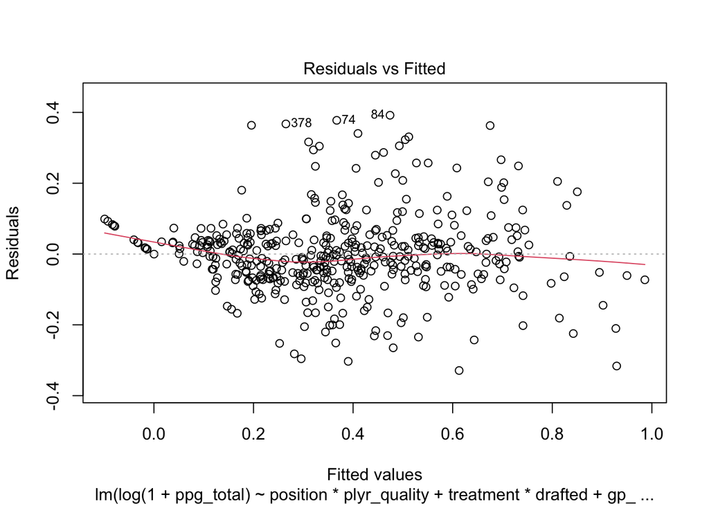

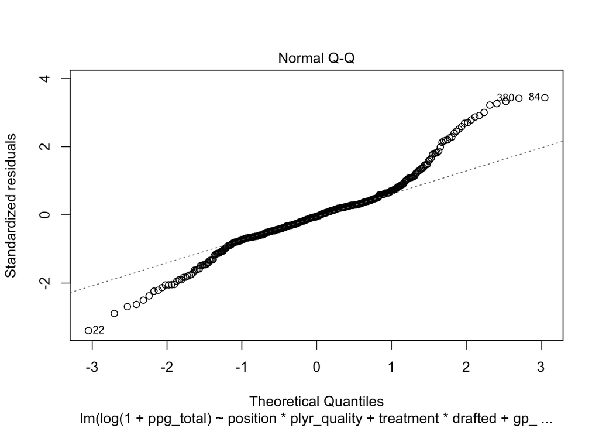

```
##
## Call:
## lm(formula = log(1 + ppg_total) ~ position * plyr_quality + treatment *
##     drafted + gp_total + plyr_quality * gp_total + plyr_quality *
##     drafted + age_continuous * plyr_quality + season, data = ohl_filtered)
##
## Residuals:
##      Min       1Q   Median       3Q      Max
## -0.32901 -0.05826 -0.00607  0.04456  0.39200
##
## Coefficients:
##                              Estimate Std. Error t value Pr(>|t|)
## (Intercept)                  0.183278   0.177310   1.034  0.30188
## positionF                    0.084160   0.019499   4.316 1.98e-05 ***
## plyr_quality                 0.865576   0.307600   2.814  0.00512 **
## treatmentPlayed              0.002898   0.019956   0.145  0.88459
## draftedTRUE                  0.071914   0.026330   2.731  0.00657 **
## gp_total                     0.002811   0.000468   6.007 4.06e-09 ***
## age_continuous              -0.017665   0.010352  -1.707  0.08864 .
## season2021-2022              0.208512   0.019967  10.443  < 2e-16 ***
## positionF:plyr_quality      -0.077930   0.057386  -1.358  0.17518
## treatmentPlayed:draftedTRUE  0.020942   0.034931   0.600  0.54915
## plyr_quality:gp_total       -0.001254   0.001233  -1.017  0.30985
## plyr_quality:draftedTRUE    -0.096164   0.052643  -1.827  0.06844 .
## plyr_quality:age_continuous -0.007997   0.016939  -0.472  0.63712
## ---
## Signif. codes:  0 '***' 0.001 '**' 0.01 '*' 0.05 '.' 0.1 ' ' 1
##
## Residual standard error: 0.1146 on 425 degrees of freedom
## Multiple R-squared:  0.7686, Adjusted R-squared:  0.7621
## F-statistic: 117.7 on 12 and 425 DF,  p-value: < 2.2e-16
```

Takeaways:

- Does not improve upon previous model modeling PPG, maybe even worse.

#### Transform PPG -> sqrt(1 + PPG)

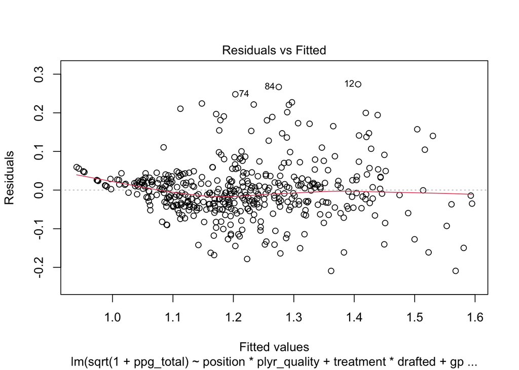

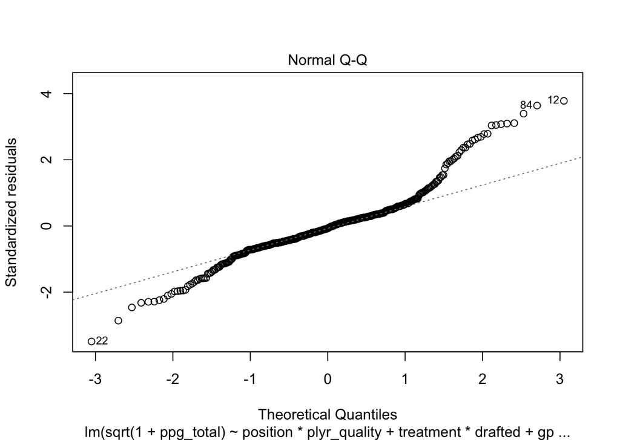

```
##
## Call:
## lm(formula = sqrt(1 + ppg_total) ~ position * plyr_quality +
##     treatment * drafted + gp_total + plyr_quality * gp_total +
##     plyr_quality * drafted + age_continuous * plyr_quality +
##     season, data = ohl_filtered)
##
## Residuals:
##       Min        1Q    Median        3Q       Max
## -0.209227 -0.037682 -0.005305  0.026890  0.273866
##
## Coefficients:
##                               Estimate Std. Error t value Pr(>|t|)
## (Intercept)                  1.1844952  0.1139609  10.394  < 2e-16 ***
## positionF                    0.0472054  0.0125325   3.767 0.000189 ***
## plyr_quality                 0.3270471  0.1977004   1.654 0.098814 .
## treatmentPlayed              0.0012675  0.0128263   0.099 0.921325
## draftedTRUE                  0.0395618  0.0169231   2.338 0.019864 *
## gp_total                     0.0014869  0.0003008   4.943 1.11e-06 ***
## age_continuous              -0.0150411  0.0066532  -2.261 0.024281 *
## season2021-2022              0.1329864  0.0128335  10.362  < 2e-16 ***
## positionF:plyr_quality      -0.0298963  0.0368832  -0.811 0.418067
## treatmentPlayed:draftedTRUE  0.0132330  0.0224507   0.589 0.555890
## plyr_quality:gp_total       -0.0002172  0.0007926  -0.274 0.784167
## plyr_quality:draftedTRUE    -0.0408806  0.0338347  -1.208 0.227625
## plyr_quality:age_continuous  0.0038789  0.0108871   0.356 0.721805
## ---
## Signif. codes:  0 '***' 0.001 '**' 0.01 '*' 0.05 '.' 0.1 ' ' 1
##
## Residual standard error: 0.07366 on 425 degrees of freedom
## Multiple R-squared:  0.756,  Adjusted R-squared:  0.7491
## F-statistic: 109.7 on 12 and 425 DF,  p-value: < 2.2e-16
```

Takeaways:

- Does not improve upon previous model modeling PPG, maybe even worse.

### Non-interaction GLM Gamma inverse link

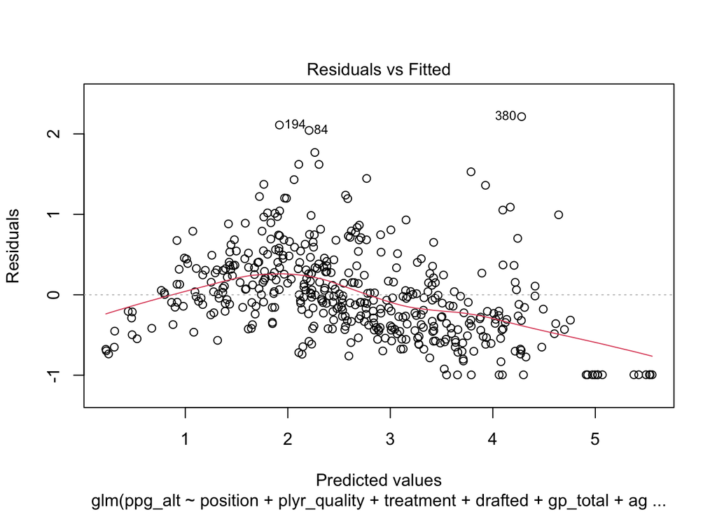

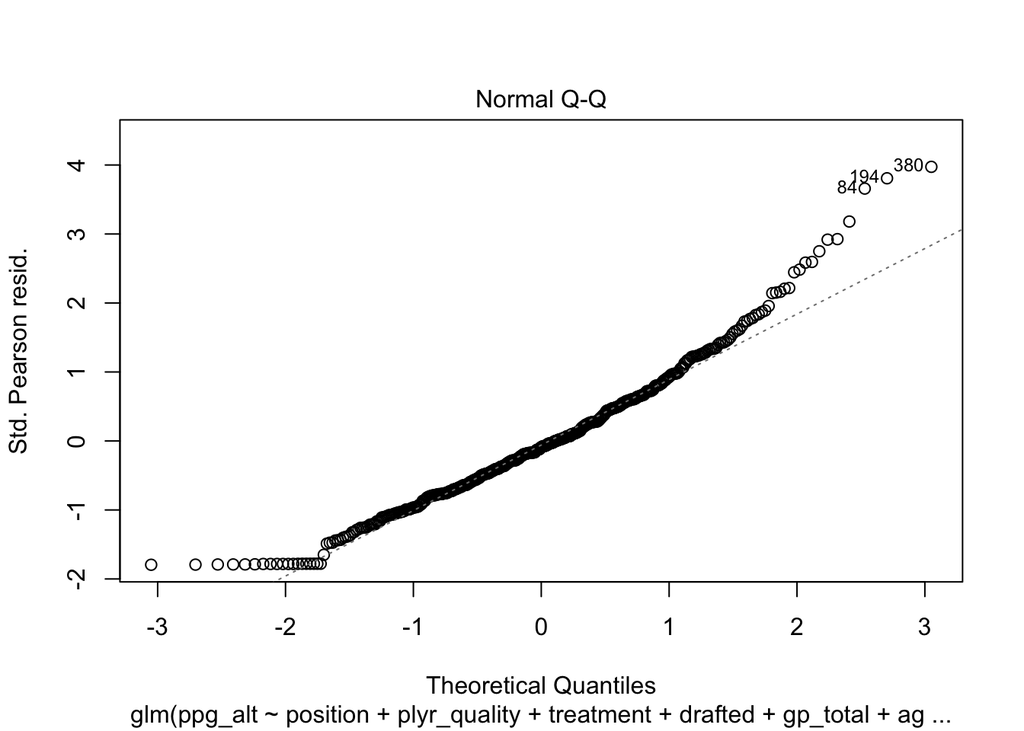

```
##
## Call:
## glm(formula = ppg_alt ~ position + plyr_quality + treatment +
##     drafted + gp_total + age_continuous + season, family = Gamma,
##     data = ohl_filtered)
##
## Deviance Residuals:
##      Min        1Q    Median        3Q       Max
## -3.04781  -0.45634  -0.05151   0.29262   1.44723
##
## Coefficients:
##                 Estimate Std. Error t value Pr(>|t|)
## (Intercept)      6.74752    1.10045   6.132 1.97e-09 ***
## positionF       -0.64466    0.15355  -4.198 3.27e-05 ***
## plyr_quality    -1.60164    0.16448  -9.737  < 2e-16 ***
## treatmentPlayed  0.08761    0.11320   0.774   0.4394
## draftedTRUE     -0.27769    0.11582  -2.398   0.0169 *
## gp_total        -0.03088    0.00474  -6.515 2.04e-10 ***
## age_continuous  -0.06439    0.06242  -1.032   0.3029
## season2021-2022 -0.71982    0.16649  -4.324 1.91e-05 ***
## ---
## Signif. codes:  0 '***' 0.001 '**' 0.01 '*' 0.05 '.' 0.1 ' ' 1
##
## (Dispersion parameter for Gamma family taken to be 0.3145594)
##
##     Null deviance: 428.22  on 437  degrees of freedom
## Residual deviance: 278.76  on 430  degrees of freedom
## AIC: 70.451
##
## Number of Fisher Scoring iterations: 6
```

Takeaways:

- This model does not adequately capture the relationship between our predictors and response.
- **Note**: Tried to fit a GLM with interaction using the default Gamma link function (inverse), but it threw an error and said “no valid set of coefficients has been found: please supply starting values”

#### Interaction GLM using Gamma distribution with log link function

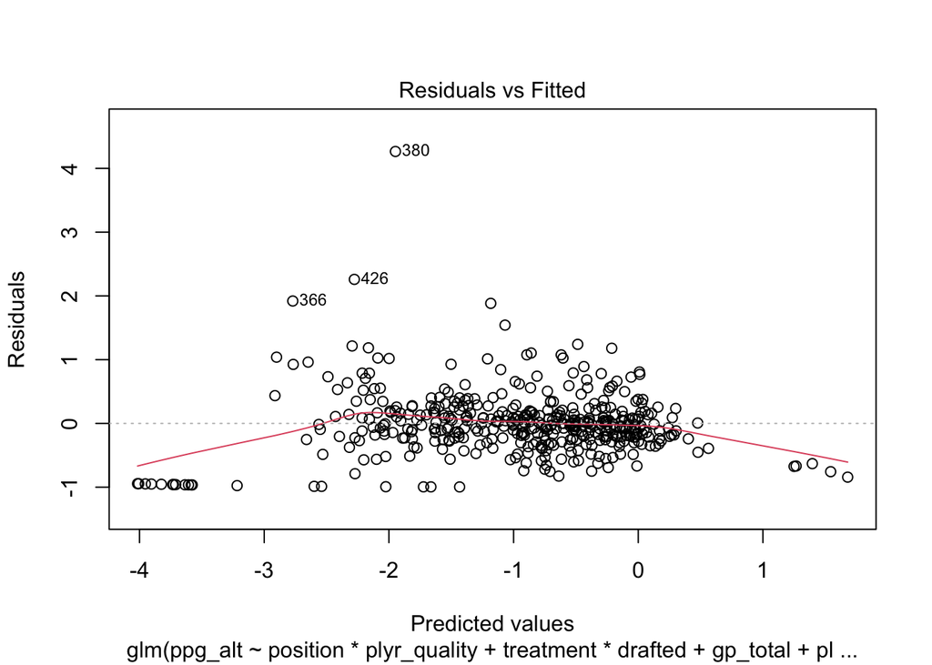

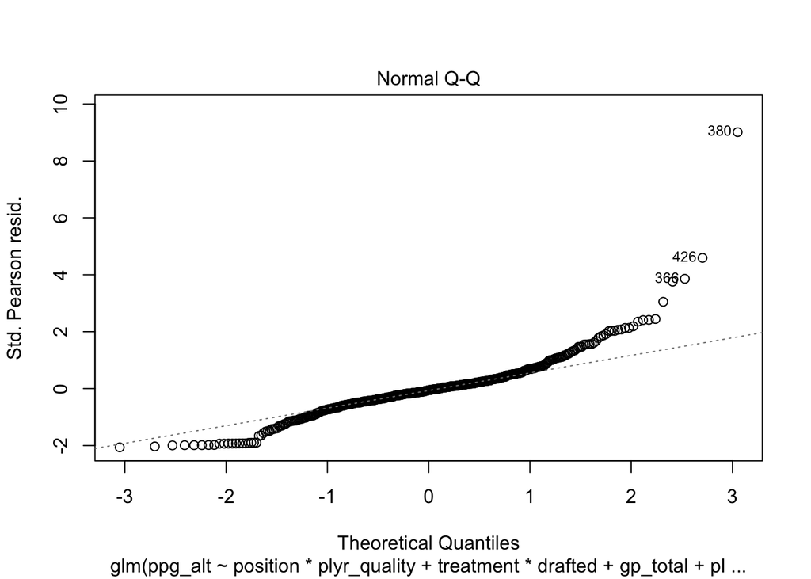

```
##
## Call:
## glm(formula = ppg_alt ~ position * plyr_quality + treatment *
##     drafted + gp_total + plyr_quality * gp_total + plyr_quality *
##     drafted + age_continuous * plyr_quality + season, family = Gamma(link = log),
##     data = ohl_filtered)
##
## Deviance Residuals:
##      Min        1Q    Median        3Q       Max
## -2.99302  -0.26334  -0.02853   0.16594   2.28235
##
## Coefficients:
##                              Estimate Std. Error t value Pr(>|t|)
## (Intercept)                 -6.116996   0.788636  -7.756 6.54e-14 ***
## positionF                    0.401587   0.086727   4.630 4.86e-06 ***
## plyr_quality                13.999425   1.368133  10.233  < 2e-16 ***
## treatmentPlayed              0.095492   0.088761   1.076  0.28261
## draftedTRUE                  0.618591   0.117112   5.282 2.04e-07 ***
## gp_total                     0.029064   0.002082  13.962  < 2e-16 ***
## age_continuous               0.120041   0.046042   2.607  0.00945 **
## season2021-2022              0.797146   0.088811   8.976  < 2e-16 ***
## positionF:plyr_quality      -0.655966   0.255240  -2.570  0.01051 *
## treatmentPlayed:draftedTRUE  0.098357   0.155364   0.633  0.52703
## plyr_quality:gp_total       -0.049748   0.005485  -9.070  < 2e-16 ***
## plyr_quality:draftedTRUE    -1.295495   0.234144  -5.533 5.52e-08 ***
## plyr_quality:age_continuous -0.459833   0.075341  -6.103 2.34e-09 ***
## ---
## Signif. codes:  0 '***' 0.001 '**' 0.01 '*' 0.05 '.' 0.1 ' ' 1
##
## (Dispersion parameter for Gamma family taken to be 0.2598456)
##
##     Null deviance: 428.22  on 437  degrees of freedom
## Residual deviance: 180.03  on 425  degrees of freedom
## AIC: -127.11
##
## Number of Fisher Scoring iterations: 13
```

Takeaways:

- This model does not adequately capture the relationship between our predictors and response (relationship appears non-linear).
- Predictions are not on the correct scale either.

#### Interaction GLM with gaussian log link function

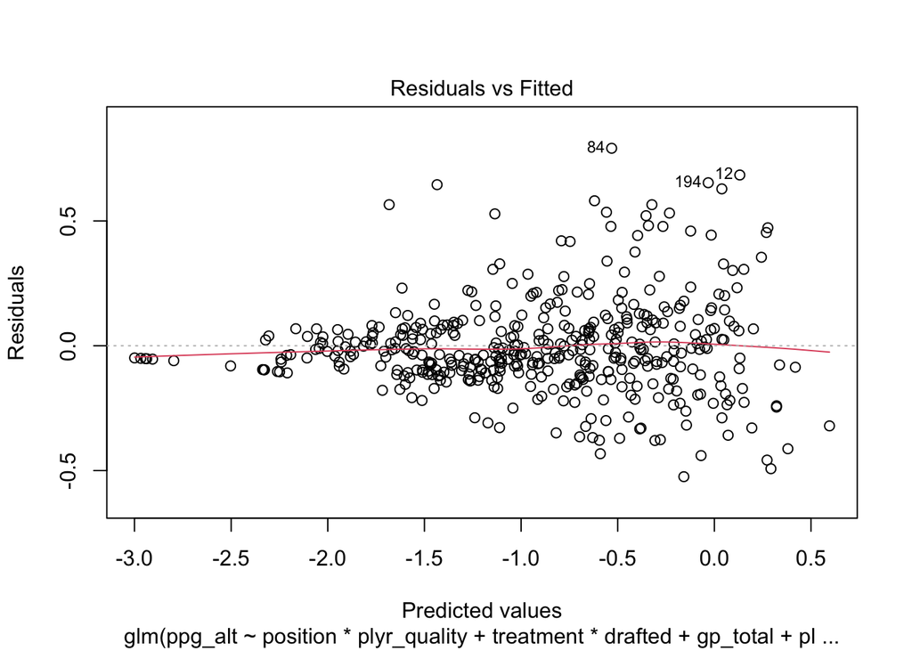

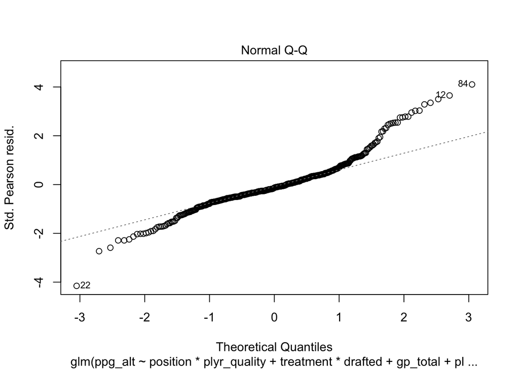

```
##
## Call:
## glm(formula = ppg_alt ~ position * plyr_quality + treatment *
##     drafted + gp_total + plyr_quality * gp_total + plyr_quality *
##     drafted + age_continuous * plyr_quality + season, family = gaussian(link = log),
##     data = ohl_filtered)
##
## Deviance Residuals:
##      Min        1Q    Median        3Q       Max
## -0.52455  -0.10400  -0.02565   0.07277   0.79096
##
## Coefficients:
##                              Estimate Std. Error t value Pr(>|t|)
## (Intercept)                 -4.799200   0.675378  -7.106 5.08e-12 ***
## positionF                    0.709110   0.095354   7.437 5.75e-13 ***
## plyr_quality                 6.320262   0.855256   7.390 7.86e-13 ***
## treatmentPlayed              0.031932   0.067900   0.470 0.638393
## draftedTRUE                  0.464459   0.082106   5.657 2.84e-08 ***
## gp_total                     0.013898   0.002486   5.590 4.06e-08 ***
## age_continuous               0.106930   0.036110   2.961 0.003236 **
## season2021-2022              0.495171   0.054993   9.004  < 2e-16 ***
## positionF:plyr_quality      -0.975732   0.189273  -5.155 3.89e-07 ***
## treatmentPlayed:draftedTRUE -0.011150   0.089273  -0.125 0.900664
## plyr_quality:gp_total       -0.009111   0.003242  -2.810 0.005177 **
## plyr_quality:draftedTRUE    -0.447553   0.124028  -3.608 0.000345 ***
## plyr_quality:age_continuous -0.198948   0.043897  -4.532 7.60e-06 ***
## ---
## Signif. codes:  0 '***' 0.001 '**' 0.01 '*' 0.05 '.' 0.1 ' ' 1
##
## (Dispersion parameter for gaussian family taken to be 0.0376268)
##
##     Null deviance: 61.100  on 437  degrees of freedom
## Residual deviance: 15.991  on 425  degrees of freedom
## AIC: -178.87
##
## Number of Fisher Scoring iterations: 7
```

Takeaways:

- Non-constant variance, not normally distributed towards lower predicted values
- Models relationship better than previous models
- Not predicting PPG on the right scale

### Questions/Concerns

- Next steps for modeling?
- Are we using BART to get propensity scores?

…